# Generate missing values with ampute

#### Scatterplots

Similar inspections can be done using the function `xyplot`. The scatterplots show the correlation between the variable values and the weighted sum scores. For the fourth pattern, the scatterplots are as follows.

```
## $`Scatterplot Pattern 4`
```

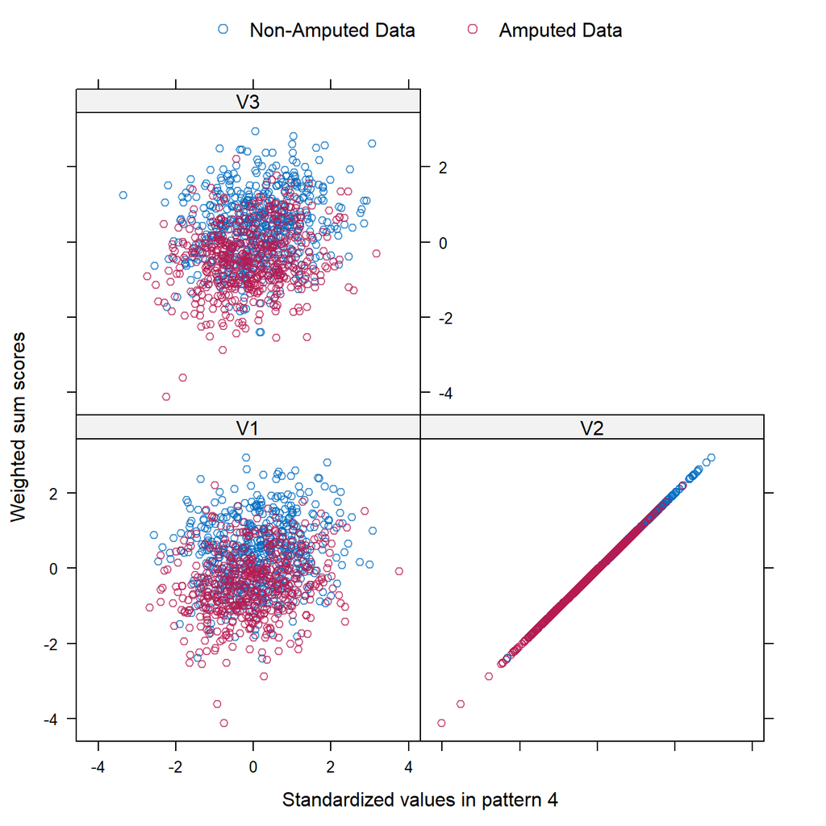

```r
xyplot(result, which.pat = 4)
```

1. The amputed data is on the left hand side of the weighted sum scores. This is due to the `type` setting: we specified a `LEFT` probability distribution.
2. There is a perfect correlation between variable V2 and the weighted sum scores. Clearly, pattern 4 depends on variable V2 only. This is exactly as we specified in the weights matrix.

Note that there are other R-packages with nice functions to visualize missing data patterns. An example is package [**naniar**](http://naniar.njtierney.com/articles/naniar-visualisation.html) from Nicholas Tierney.

#### Argument `run`

It may be desirable to quickly run `ampute` without actually executing the amputation procedure. An empty run will generate the default argument values, which can then be adapted as desired. This can be especially useful for large datasets. For an empty run, the argument `run` can be set to `FALSE`.

```r
emptyresult <- ampute(testdata, run = FALSE)
emptyresult$amp
```

```
## data frame with 0 columns and 0 rows
```

### Special solutions for special cases

#### Missingness proportion per variable

Sometimes, we wish to determine the missingness proportion per variable (and not for the number of incomplete rows, or the number of missing cells). At first sight, this is easy to accomplish by using the default patterns matrix as this will create patterns with missingness in 1 variable only and then specifying the proportion with the `prop` argument.

However, for datasets with a small N:M ratio, this can give problems. For instance, the Boston dataset in the **MASS** package has 506 data rows and 14 variables. Let’s say we wish to create 30% missing values in each of the columns.

```r
data <- MASS::Boston
dim(data)
```

```
## [1] 506  14
```

With the default settings in `ampute` and `prop = 0.3`, the function will divide 506 rows over 14 patterns, resulting in approximately 36 data rows per subset. The function will then ampute `0.3 * 36 = 11` rows per pattern. In total, this will give a missingness proportion per variable of `11 / 506 = 0.02` wich is clearly not what we desired!

In order to reach 30% missingness in each variable in the Boston dataset, `0.3 * 506 = 152` data rows per subset should be made incomplete. This means that at least `152 / 36 = 422%` of the available data rows in each subset should be amputed. Obviously, this is not possible.

We will present two possible solutions.

**In solution 1** we first create masks for every variable separately, and then apply the masks at the end. The following steps should be taken:

For every i in 1:14:

1. create a temporary dataset for all variables but i
2. standardize that dataset
3. calculate the weighted sum scores as desired
4. use `ampute.continuous` to generate a mask that indicates which rows should become incomplete

When you have the masks for all variables, apply the masks.

```r
# for instance for i = 1
# step 1 and 2
data_withoutvar1 <- data[, c(2:14)]
std_datawithoutvar1 <- scale(data_withoutvar1)

# step 3
# we generate only 1 pattern so the weights matrix has to contain 1 row
# specify the weights as desired
# here we use 1 for all variables,
# indicating that we use all variables - i to create missingness in variable i
# which is a MAR mechanism
weights <- matrix(rep(1, 13), nrow = 1)
my_scores <- apply(std_datawithoutvar1, 1, function (x) weights %*% x)

# step 4
# P has to be set to 2 for all rows in the dataset
# meaning that all rows are candidates for this pattern
# specify the probability distribution with argument type
# and the desired missingness proportion
mask_var1 <- ampute.continuous(P = rep(2, nrow(data_withoutvar1)),
                               scores = list(my_scores), prop = 0.3, type = "RIGHT")

# in the mask, 0 indicates the row should become incomplete,
# 1 means the row should stay complete
mask_var1
```

```
## [[1]]
##   [1] 1 1 1 1 1 1 1 0 1 0 1 1 1 1 1 1 1 0 1 1 1 1 1 1 1 1 1 1 0 0 1 1 1 1 0 1 1
##  [38] 1 1 1 1 1 1 1 1 1 1 1 1 1 1 1 1 1 1 1 1 1 1 1 1 1 1 0 1 1 1 1 1 1 1 1 1 1
##  [75] 1 1 1 1 1 1 1 1 1 1 1 1 1 1 1 1 1 1 1 1 1 1 1 1 1 1 0 0 1 1 1 1 1 1 1 1 1
## [112] 1 1 1 0 1 1 1 1 1 1 1 1 1 1 1 0 0 0 1 0 0 1 0 1 0 0 0 0 0 0 0 0 1 0 1 1 0
## [149] 1 1 0 1 0 1 0 0 1 0 1 1 0 0 0 0 1 1 0 1 1 1 1 1 1 1 1 1 1 1 1 1 1 1 1 1 1
## [186] 1 1 1 1 1 1 1 1 1 1 1 1 1 1 1 1 1 1 0 1 1 1 1 1 0 0 0 0 1 1 1 0 1 0 1 0 1
## [223] 0 1 0 1 1 1 1 1 1 1 1 1 0 1 0 1 1 1 0 1 1 1 1 1 1 1 1 1 1 1 1 0 1 1 0 1 1
## [260] 1 1 1 0 1 1 1 1 1 1 0 1 1 1 0 1 1 0 0 1 1 1 1 0 0 0 1 1 1 0 1 1 1 1 1 1 1
## [297] 1 1 1 1 1 1 1 1 1 1 1 1 1 1 1 1 1 1 1 1 1 1 1 1 1 1 1 1 1 1 1 1 1 1 1 1 1
## [334] 1 1 1 1 1 1 1 1 1 1 1 0 1 1 1 1 1 1 1 1 0 0 0 0 0 0 0 0 0 0 0 0 0 0 1 0 0
## [371] 0 0 0 0 0 0 0 0 0 0 0 0 0 0 1 0 0 0 0 0 0 0 0 0 0 0 0 0 0 0 0 0 0 0 0 0 0
## [408] 0 0 0 1 0 0 0 0 0 1 0 0 0 0 0 0 0 1 1 0 1 1 0 1 0 0 0 0 0 0 0 0 0 0 0 0 0
## [445] 1 0 0 0 0 0 1 0 0 0 0 1 0 1 0 0 0 0 0 0 0 0 0 0 0 0 1 0 0 0 0 0 0 0 0 0 0
## [482] 0 0 0 0 0 0 0 0 0 0 0 0 1 1 1 1 1 1 1 0 1 1 1 1 1
```

Note that this procedure of first calculating the masks and then applying those masks will pose a problem for the quality of the MAR mechanism. Here, we use all observed data to generate the missing values, but later we will ampute the observed data with another mask. Hence, this approach will create a weak MNAR mechanism and not purely MAR.

**In solution 2** we decide to generate the missingness by using 3 patterns instead of 14:

```r
my_pat <- matrix(c(rep(0, 5), rep(1, 9),
                   rep(1, 5), rep(0, 5), rep(1, 4),
                   rep(1, 10), rep(0, 4)), nrow = 3, byrow = TRUE)
```

With this approach, all variables will become incomplete, but the data rows will have more than 1 missing value. Be aware that the missing data method that will be used has to be able to deal with this.

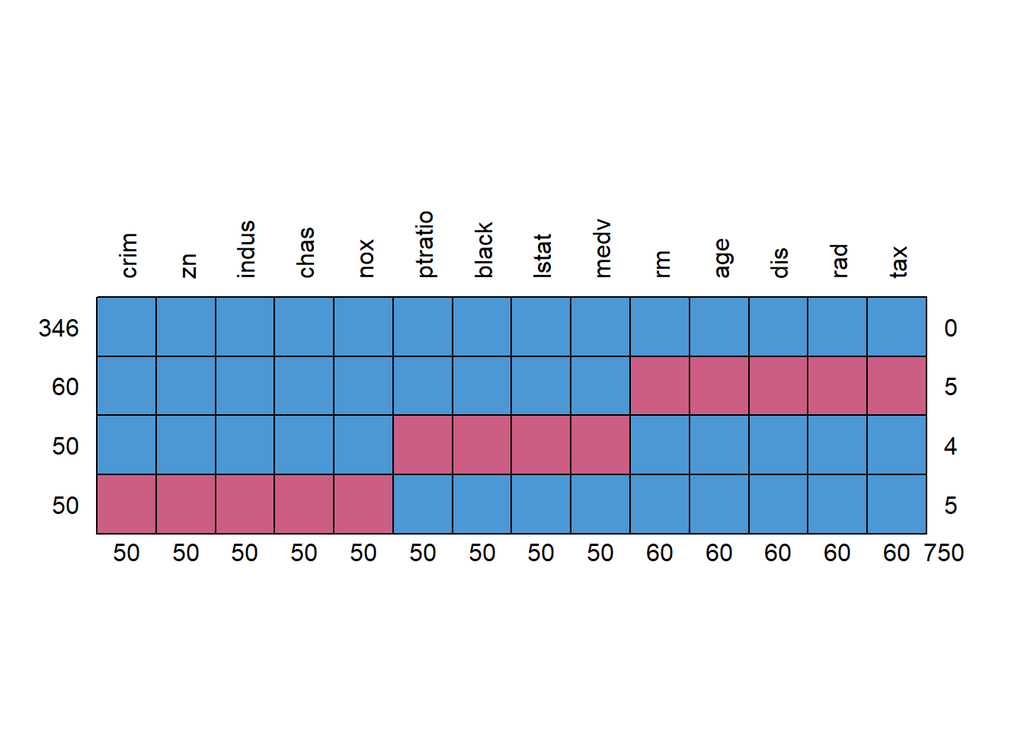

```
##     crim zn indus chas nox ptratio black lstat medv rm age dis rad tax
## 346    1  1     1    1   1       1     1     1    1  1   1   1   1   1   0
## 60     1  1     1    1   1       1     1     1    1  0   0   0   0   0   5
## 50     1  1     1    1   1       0     0     0    0  1   1   1   1   1   4
## 50     0  0     0    0   0       1     1     1    1  1   1   1   1   1   5
##       50 50    50   50  50      50    50    50   50 60  60  60  60  60 750
```

```r
solution2 <- ampute(data, prop = 0.3, patterns = my_pat)
md.pattern(solution2$amp, rotate.names = TRUE)
```

#### MCAR and MAR combined

In this tutorial, we have discussed how to generate a combination of MAR and MNAR missingness using the weights matrix. Unfortunately, the generation of both MCAR and MAR missingness (or any other form of weak MAR) is currently not directly possible with `ampute`. The following code shows how a combination of MCAR and MAR can still be created.

```r
# ampute the complete data once for every mechanism
ampdata1 <- ampute(testdata, patterns = c(0, 1, 1), prop = 0.2, mech = "MAR")$amp
ampdata2 <- ampute(testdata, patterns = c(1, 1, 0), prop = 0.8, mech = "MCAR")$amp

# create a random allocation vector
# use the prob argument to specify how much of each mechanism should be created
# here, 0.5 of the missingness should be MAR and 0.5 should be MCAR
indices <- sample(x = c(1, 2), size = nrow(testdata),
                  replace = TRUE, prob = c(0.5, 0.5))

# create an empty data matrix
# fill this matrix with values from either of the two amputed datasets
ampdata <- matrix(NA, nrow = nrow(testdata), ncol = ncol(testdata))
ampdata[indices == 1, ] <- as.matrix(ampdata1[indices == 1, ])
ampdata[indices == 2, ] <- as.matrix(ampdata2[indices == 2, ])
```

#### Argument `odds`

Function `ampute` provides 4 logistic probability distributions that are used to translate a weighted sum score into a probability of being amputed. By default, in order to use these distributions, we set the argument `cont == TRUE`.

However, when `cont == FALSE`, the user has the possibility to define the probability values manually by means of the `odds` argument. When using odds values:

1. The weighted sum scores of all candidates in a subset are divided over a certain number of equally sized groups, or quantiles. The number of groups can differ between patterns.
2. An odds value defines the relative probability of each quantile group of becoming incomplete.

The odds are specified by means of a matrix, and the default is as follows. The number of rows indicates the number of patterns, which is 4 in this tutorial. The number of columns determines the number of equally sized groups. Here, for each pattern, the weighted sum scores are divided over 4 groups.

```r
myodds <- result$odds
myodds
```

```
##      [,1] [,2] [,3] [,4]
## [1,]    1    2    3    4
## [2,]    1    2    3    4
## [3,]    1    2    3    4
## [4,]    1    2    3    4
```

The values `1, 2, 3, 4` indicate that a data row with a weighted sum score in the highest quantile (last value) has a probability of becoming incomplete that is four times as large (last value is a 4) as a data row with a weighted sum score in the lowest quantile (first value is 1).

We can adapt the odds matrix as follows. For pattern 3, we keep the four quantiles but we assign a `0` for positions 2 and 3. This means that data rows with an average weighted sum score (quantile 2 and 3) have a zero probability of becoming incomplete.

For pattern 4, we let data rows with an average weighted sum score (two center quantiles) have a twice as large probability of becoming incomplete than data rows with extreme weighted sum scores (odds values are 2 and 1). Since we assign 6 values to the odds matrix, the weighted sum scores of subset 4 are divided into 6 quantiles.

```r
myodds[3, ] <- c(1, 0, 0, 1)
myodds[4, ] <- c(1, 1, 2, 2)
myodds <- cbind(myodds, matrix(c(NA, NA, NA, 1, NA, NA, NA, 1), nrow = 4, byrow = F))
myodds
```

```
##      [,1] [,2] [,3] [,4] [,5] [,6]
## [1,]    1    2    3    4   NA   NA
## [2,]    1    2    3    4   NA   NA
## [3,]    1    0    0    1   NA   NA
## [4,]    1    1    2    2    1    1
```

```r
result <- ampute(testdata, freq = myfreq, patterns = mypatterns,
                 weights = myweights, cont = FALSE, odds = myodds, prop = 0.3)
```

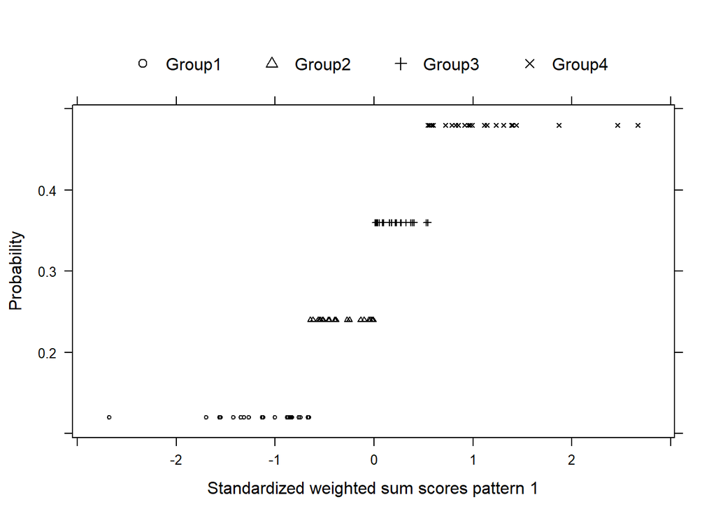

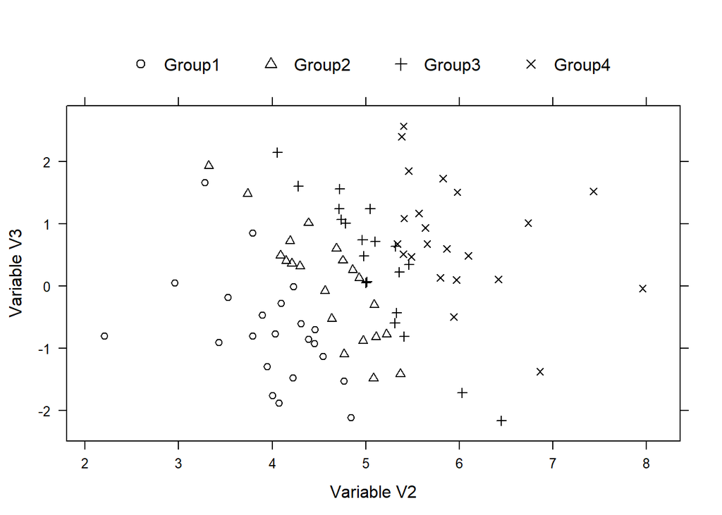

Figure 5 shows the relation between the quantiles and the variable values. Because in pattern 1, variables V2 and V3 are both uses to calculate the weighted sum scores (remember the weights matrix), the groups can be distinguished well.

We see that cases with a high value on V2, are more often in group 4 than in group 1. Group 4 contains the higher weighted sum scores. Hence, cases with a high value on V2, have a higher weighted sum score. Again, this is exactly as we specified the weights matrix. For variable V3, the relation between the values and the group allocation is less distinct but still present.

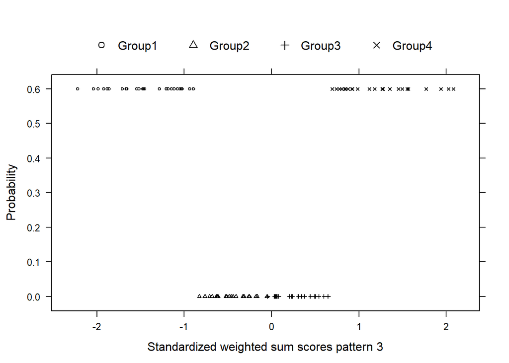

Figure 6 shows the probabilities for 100 candidates for pattern 3. We see that data rows with average weighted sum scores, have a zero probability of being amputed. The data rows with extreme sum scores have a probability of 0.6 of becoming incomplete. Since the odds values are similar for the lowest and highest quantile, the probabilities for these two subgroups are equal.

### Go ahead and `ampute`!

For questions or comments regarding `ampute` or the amputation methodology, contact Rianne Schouten. Find her [contact details here](https://rianneschouten.github.io/#contact).

**News!** Multivariate amputation is now available in Python as well; in library [`pyampute`](https://rianneschouten.github.io/pyampute/build/html/index.html).

### References

Brand, Jaap. 1999. “Development, Implementation and Evaluation of Multiple Imputation Strategies for the Statistical Analysis of Incomplete Data Sets.” PhD thesis.

Schouten, Rianne Margaretha, Peter Lugtig, and Gerko Vink. 2018. “Generating Missing Values for Simulation Purposes: A Multivariate Amputation Procedure.” *Journal of Statistical Computation and Simulation* 88 (15): 2909–30.

Schouten, Rianne Margaretha, and Gerko Vink. 2021. “The Dance of the Mechanisms: How Observed Information Influences the Validity of Missingness Assumptions.” *Sociological Methods & Research* 50 (3): 1243–58.

Van Buuren, Stef. 2018. *Flexible Imputation of Missing Data*. CRC press.